# CaseStudy2

Morgan Nelson

3/20/2020

Greetings and welcome,

Thank you for giving DDS Analytics the opportunity to help you answer the age old question, “Why do my employees leave?” In the course of this analysis, we identified the top three factors that indicate employee turnover. For this analysis, we targetted an 80% or better accuracy, with a 60% or better result in both false positives and false negative, increasing confidence in the model well above that of random chance (50/50), or simply providing a “No” response to the question of “Will this particular employee leave in the next year?” That from this dataset, would actually be correct about 80% of the time We began by getting familiar with the data you provided, and started to develop an understanding of your employees. We did this by graphing values, looking for correlations, and transforming data.

# Exploratory Data Analysis

After performing the initial Exploratory Data Analysis, it was decided to remove the following columns from the dataset:

- ID - meaningful only to the database
- EmployeeCount - always “1” and adds nothing to the analysis
- EmployeeNumber - meaningful only to HR
- Over18 - Always “Y” and adds nothing to the analysis
- StandardHours - Always 80 and adds nothing to the analysis

This left us with only the data that provided a possibly meaningful impact on employee turnover.

Based on the visual output from graphing the histograms of the continuous variables, it appears that some of the distributions are not normal and appear to be more logarithmic in nature, tending to a severe right skew. We tried transforming the data, but with the exception of **TotalWorkingYears**, it did not correct the data. We did not need to transform the data to reach our target numbers.

## Attrition Percentages

We then looked at the percentage of attrition present in each group, creating a table of values for each. The full data is in the RMarkdown file provided separately.

```r
# let's look at attrition rates for individual variables

cs2.kept %>% group_by(BusinessTravel) %>% summarise(AttritionPercent = sum(as.numeric(Attrition)-1)/n(), totalPeople = n())
```

| BusinessTravel | AttritionPercent | totalPeople |
| --- | --- | --- |
| Non-Travel | 0.1170213 | 94 |
| Travel_Frequently | 0.2215190 | 158 |
| Travel_Rarely | 0.1521036 | 618 |

## ANOVA Analysis

We also ran ANOVA variance analysis to get concrete numbers for the correlation of each variable with the goal, “Attrition”. From this analysis, we were able to determine the three variables that most significantly contributed to employee turnover:

- TotalWorkingYears
- JobInvolvement
- OverTime

```r
# reduce the set of "most important factors" to three
summary(aov(AttrYes ~ TotalWorkingYears + JobInvolvement + OverTime, data = cs2.kept))
```

```
##                    Df Sum Sq Mean Sq F value   Pr(>F)
## TotalWorkingYears   1   3.28   3.284   27.89 1.63e-07 ***
## JobInvolvement      1   4.25   4.247   36.06 2.81e-09 ***
## OverTime            1   7.95   7.945   67.46 7.79e-16 ***
## Residuals         866 101.99   0.118
## ---
## Signif. codes:  0 '***' 0.001 '**' 0.01 '*' 0.05 '.' 0.1 ' ' 1
```

## Create a Model

Now that we have the top three variables, we can create a mathematical model for predicting employee turnover. We start with the k-Nearest Neighbors or k-NN model as this is easy to both implement and understand. We find a *distance* from the data point we wish to predict as either “Leaving” or “Not Leaving” and the closest data point we already have. If the majority of the new data points *Nearest Neighbors* have left the company, we predict this one will as well.

### One More Thing

Another point of interest in the data model was identified. The fact that the data we have represents approximately 80% employees who have not left the company, and only approximately 20% employess who have left the company creates an imbalanced data set that can throw off our k-NN model. Ideally, when attempting to classify a ppopulation into two categories, we would want the known data to be approximately 50% one category and 50% the other. To fixup this data, we have decided to use “**SMOTE**” or **Synthetic Minority Oversampling TEchnique** to bring the data set closer to the ideal. **SMOTE** creates additional samples in the data set based on the existing samples of the minority value. In this case, it will generate enough “Left” samples to balance out the “Did not leave” group, and give the k-NN a higher probability of success.

```r
predictions <- predict(knn_fit, newdata = test_set)
confusionMatrix(predictions, test_set$Attrition)
```

```
## Confusion Matrix and Statistics
##
##           Reference
## Prediction  0  1
##          0 58 21
##          1  5 35
##
##                Accuracy : 0.7815
##                  95% CI : (0.6965, 0.852)
##     No Information Rate : 0.5294
##     P-Value [Acc > NIR] : 1.088e-08
##
##                   Kappa : 0.5544
##
##  Mcnemar's Test P-Value : 0.003264
##
##             Sensitivity : 0.9206
##             Specificity : 0.6250
##          Pos Pred Value : 0.7342
##          Neg Pred Value : 0.8750
##              Prevalence : 0.5294
##          Detection Rate : 0.4874
##    Detection Prevalence : 0.6639
##       Balanced Accuracy : 0.7728
##
##        'Positive' Class : 0
##
```

# Salary

Next, we were asked to find the Salary of employees from the data in the model, with a Root Mean Squared Error of less than $3000. To do this, we will build a multiple linear regression model using a stepwise iterative approach. The assumptions from above RE: unneccessary data still hold, and we will leave those out as well.

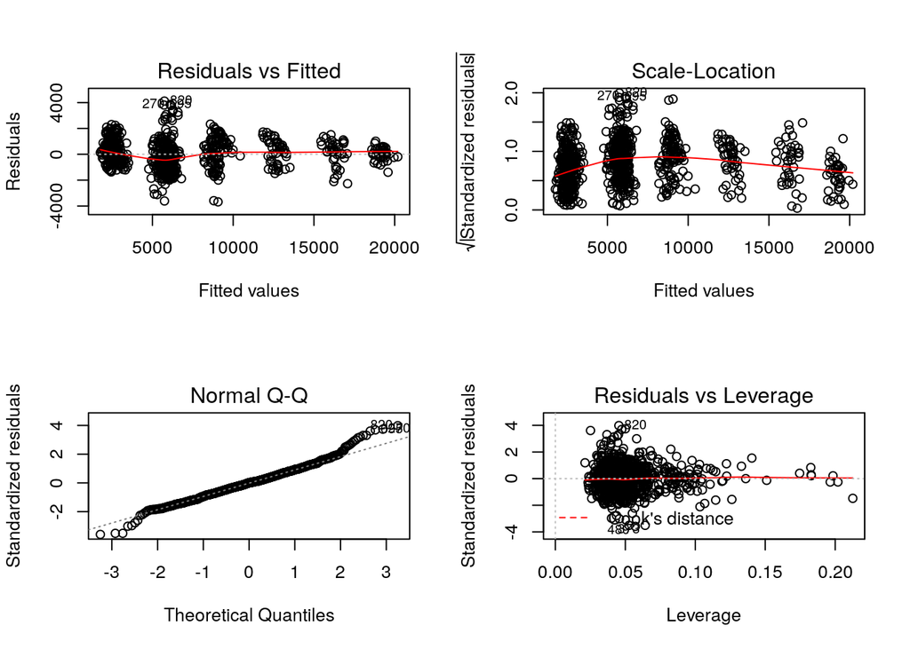

```r
layout(matrix(c(1,2,3,4),2,2))
plot(lin_fit)
```

From these graphs, there is no evidence to suggest our model is working with unmet assumptions, so we will continue.

The stepwise regression outcome gives us a final model of:

MonthlyIncome predicted by: BusinessTravel + DailyRate + DistanceFromHome + Gender + JobLevel + JobRole + MonthlyRate + PercentSalaryHike + PerformanceRating + TotalWorkingYears + YearsSinceLastPromotion + YearsWithCurrManager

Pluging that into the software, we can find the Root Mean Square Error: 1034

```r
RMSE <- sqrt((c(crossprod(residuals(lin_fit))) / length(residuals(lin_fit))))
RMSE
```

```
## [1] 1034.554
```

And a model equation describing **MonthlyIncome** as:

MonthlyIncome = 246.97 + 223.32(BusinessTravel(Travel_Frequently)) + 390.73(BusinessTravel(Travel_Rarely)) + 14.992(DailyRate) - 6.68(DistanceFromHome) + 113.69(Gender-male) + 2789.60(JobLevel) - 363.48(JobRole(Human Resources)) - 596.72(JobRole(Laboratory Technician)) + 4125.71(JobRole(Manager)) + 167.73(JobRole(Manufacturing Director)) + 4033.20(JobRole(ResearchDirector)) - 353.78(JobRole(Research Scientist)) - 4.45(JobRole(Sales Executive)) - 456.02(JobRole(Sales Representative)) - 0.92(MonthlyRate) + 23.76(PercentSalaryHike) - 306.63(PerformanceRating) + 48.20(TotalWorkingYears) + 29.92(YearsSinceLastPromotion) - 27.90(YearsWithCurrentManager)

## Additional Job Role Specific Findings

Additionally, we were asked to provide any insights into Job Role specific trends in the data.

```r
cs2.kept %>% group_by(JobRole) %>% summarise(HighlySatisfied = sum(JobSatisfaction == 4)/n(), MostlySatisfied = sum(JobSatisfaction == 3)/n(), SortaSatisfied = sum(JobSatisfaction == 2)/n(), Dissatisfied = sum(JobSatisfaction == 1)/n(), totalPeople = n()) %>% arrange(., desc(HighlySatisfied))
```

| JobRole | HighlySatisfied | MostlySatisfied | SortaSatisfied | Dissatisfied | totalPeople |
| --- | --- | --- | --- | --- | --- |
| Healthcare Representative | 0.3684211 | 0.3026316 | 0.1184211 | 0.2105263 | 76 |
| Research Scientist | 0.3546512 | 0.2790698 | 0.1802326 | 0.1860465 | 172 |
| Sales Executive | 0.3300000 | 0.3050000 | 0.1250000 | 0.2400000 | 200 |
| Laboratory Technician | 0.3071895 | 0.2810458 | 0.2026144 | 0.2091503 | 153 |
| Sales Representative | 0.3018868 | 0.2641509 | 0.2641509 | 0.1698113 | 53 |
| Manufacturing Director | 0.2643678 | 0.3333333 | 0.2643678 | 0.1379310 | 87 |
| Manager | 0.2549020 | 0.2352941 | 0.2745098 | 0.2352941 | 51 |
| Human Resources | 0.2222222 | 0.2962963 | 0.2962963 | 0.1851852 | 27 |
| Research Director | 0.2156863 | 0.3137255 | 0.2156863 | 0.2549020 | 51 |

Your Healthcare Representative are the most satisfied, while your Research Directors are the least likely to be highly satisfied with their job role. The Research Directors are also most likely to be dissatisfied with their job role.

```r
cs2.kept %>% group_by(JobRole) %>% summarise(Married = sum(MaritalStatus == "Married")/n(), Single = sum(MaritalStatus == "Single")/n(), Divorced = sum(MaritalStatus == "Divorced")/n(), totalPeople = n()) %>% arrange(., desc(Married, Single, Divorced))
```

| JobRole | Married | Single | Divorced | totalPeople |
| --- | --- | --- | --- | --- |
| Manager | 0.6078431 | 0.2156863 | 0.1764706 | 51 |
| Research Director | 0.5490196 | 0.1960784 | 0.2549020 | 51 |
| Manufacturing Director | 0.5057471 | 0.2183908 | 0.2758621 | 87 |
| Healthcare Representative | 0.5000000 | 0.2631579 | 0.2368421 | 76 |
| Human Resources | 0.4814815 | 0.2222222 | 0.2962963 | 27 |
| Laboratory Technician | 0.4640523 | 0.3529412 | 0.1830065 | 153 |
| Sales Executive | 0.4500000 | 0.3250000 | 0.2250000 | 200 |
| Research Scientist | 0.4302326 | 0.3372093 | 0.2325581 | 172 |
| Sales Representative | 0.3962264 | 0.4905660 | 0.1132075 | 53 |

Your Managers are most likely to be married, your Sales Reps are most likely to be single, and your HR staff are most likely to be divorced.

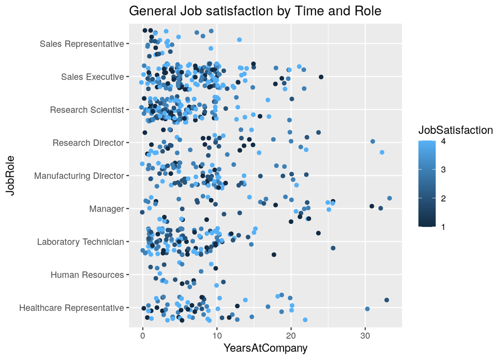

```r
cs2.kept %>% filter(Attrition == "No") %>% ggplot() + geom_point(aes(YearsAtCompany, JobRole, color = JobSatisfaction), position = "jitter") + labs(title="General Job satisfaction by Time and Role")
```

Also, assuming people who have worked at your company longer are more valuable, you seem to have several people here for more than 30 years who aren’t really satisfied with their jobs. Perhaps this is something that should be looked into?